```python
from IPython.display import HTML

HTML('''<script>
code_show=true;
function code_toggle() {
 if (code_show){
 $('div.input').hide();
 } else {
 $('div.input').show();
 }
 code_show = !code_show
}
$( document ).ready(code_toggle);
</script>
<form action="javascript:code_toggle()"><input type="submit" value="Click here to toggle on/off the raw code."></form>''')
```

# Capital One - Data Challenge Analysis

#### Submitted By : Akash Jain

#### Email : jain2ar@mail.uc.edu

#### Date : October 2, 2017

```python
from DataMunging import dataMunging
from QualityCheck import *
import numpy as np
import pandas as pd
dm = dataMunging()
fd = dm.hmda_init()
loan = dm.loanData
institutions = dm.institutionalData
import seaborn as sns
import matplotlib.pyplot as plt
%matplotlib inline
import warnings
import matplotlib.pylab as pylab
from VisualNarrative import *
warnings.filterwarnings('ignore')
```

## Analysis of Loan_Amount_000

### Check for NA or Null Values

```python
getLocationOfNAValues(fd, 'Loan_Amount_000')
```

```
{'Column': 'Loan_Amount_000', 'Count of Missing Values at index': 0}
```

**Description**  
Using getLocationOfNAValues method defined in question2.py, the results show that there are no missing or na values in Loan_Amount_000

### Distribution of Loan Amount

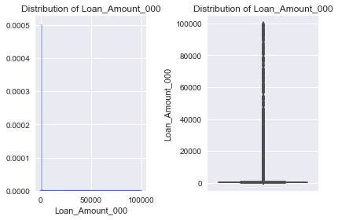

```python
fig1, axes = plt.subplots(nrows = 1, ncols = 2)
(ax1, ax2) = axes
sns.distplot(fd.Loan_Amount_000, ax=ax1)
sns.boxplot(y=fd.Loan_Amount_000, ax = ax2)
ax1.set_title('Distribution of Loan_Amount_000')
ax2.set_title('Distribution of Loan_Amount_000')
plt.tight_layout()
```

**Description**  
The distribution of loan amount is highly skewed as seen from the distribution plot which suggests that it may follow a log normal distribution.

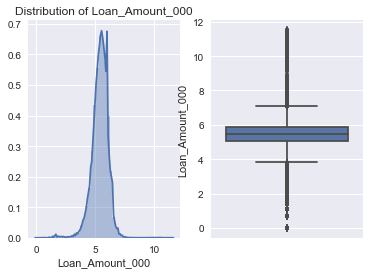

```python
fig2, axes = plt.subplots(nrows = 1, ncols = 2)
(ax1, ax2) = axes
sns.distplot(np.log(fd.Loan_Amount_000), ax=ax1)
sns.boxplot(y=np.log(fd.Loan_Amount_000), ax = ax2)
ax1.set_title('Distribution of Loan_Amount_000')
```

From the distribution plot, it is clear that Loan Amount follows a log normal distribution

## Analysis of Respondent_Name

### Check for NA or Null Values

```python
getLocationOfNAValues(fd, 'Respondent_Name_TS')
```

```
{'Column': 'Respondent_Name_TS', 'Count of Missing Values at index': 0}
```

**Description**  
There are no NA or Null Values in Respondent Name

```python
getFaultyRespondentName(fd)
```

```
{'Duplicate Data at index': []}
```

**Description**  
Respondent Name are unique for Agency Code and Year in the data

## Analysis of Other Variables

### County Code and County Name

```python
getLocationOfNAValues(fd, 'County_Code')
```

```
{'Column': 'County_Code', 'Count of Missing Values at index': 837}
```

```python
getLocationOfNAValues(fd, 'County_Name')
```

```
{'Column': 'County_Name', 'Count of Missing Values at index': 837}
```

### Duplicated Data in Loan, Institutions and Merged Dataset

```python
getDuplicateRecords(loan, 'loan')
```

```
{'Duplicate Data at index': []}
```

```python
getDuplicateRecords(institutions,'institution')
```

```
{'Duplicate Data at index': []}
```

```python
getDuplicateRecordsinMergedData(fd)
```

```
{'Duplicate Data at index': []}
```

**['Sequence_Number', 'Agency_Code', 'Respondent_ID', 'As_of_Year']** forms the key for loan data and there should be no duplicated records in the loan data according to this value. Similarly, **['Agency_Code', 'Respondent_ID', 'As_of_Year']** is the primary key for institution data and **['Sequence_Number', 'Agency_Code', 'Respondent_ID', 'As_of_Year']** is the primary key for merged data. According to these keys, if these datasets have duplicate values, they can hamper the results and misguide the analysis. Information about these duplicate records is important and as seen from getDuplicateRecords and getDuplicateRecordsinMergedData, there are no duplicate records in the data.

### Important fields to be considered

1. AS_of_YEAR: Year should be of the same format YYYY. Check for values which doesn't follow this format and report it. Set a rule should always be in YYYY format
2. Respondent_ID, Agency Code and Agency code description should be consistent
3. Sequence Number, Agency code, Respondent id can be used to identify a record and they should be unique
4. Loan_Amount_000 should not be null or NA and should be numeric
5. Applicant_Income_000 same rules as Loan_Amount_000
6. Loan_Purpose should be a string, not null and without NA values and should take only 3 values i.e. Purchase, Refinance and Home-Improvement
7. Loan_Type_Description can be conventional, government-insured or government-guarenteed
8. Lien_Status_Description can take first or subordinate as string values
9. State_Code should be of two characters and should be unique for every state
10. State should be alphabetic, two characters and should conform to the list of states

## Market Share Analysis

#### Should Change Financial enter the home loan market?

**Hypothesis**  
Change Financial should enter the home loan market with major focus on Refinance loans which are both conventional and conforming with some focus towards Purchase loans with strict guildlines.

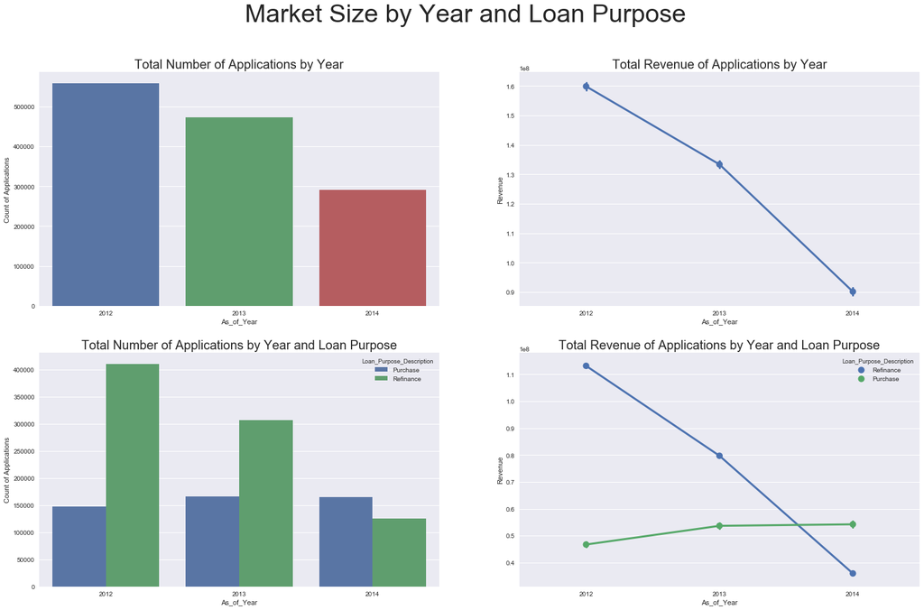

```python
createLoanAmountPlotByTimeAndLoanPurpose(fd)
```

**Analysis**  
The total number of applications for loan show a decline over the past three year and the revenue has also gone down during these past three years but Refinance Loans has always been major driver of applications and revenue. A stricking change be seen from the year 2014, though Refinance Loans has always driven the market but in 2014, market made a switch to purchase loans. A lot number of factors can cause this shift like increase in per capita income or lucrative rates and schemes by the banks which has shifted the focus of customers towards Purchase Loans.

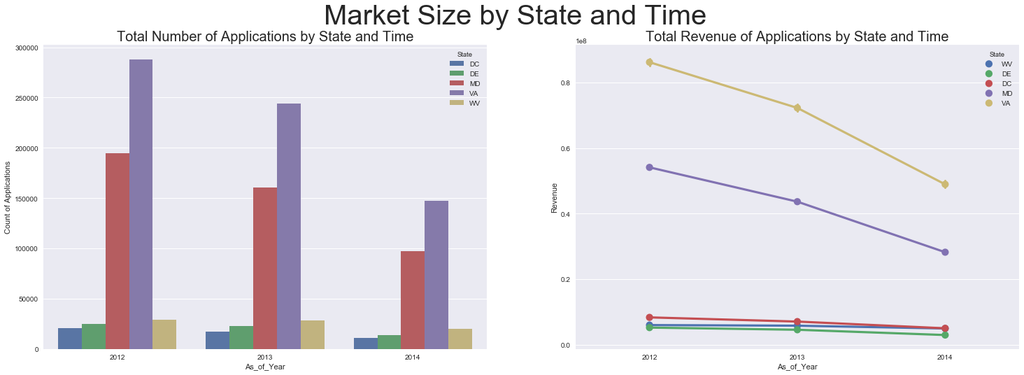

```python
createLoanAmountPlotByStateAndTime(fd)
```

**Analysis**  
The trend of count of total applications and revenue has been consistent thought the states i.e. they have declined over the years as seen from the above graphs. Virginia and Maryland have been the leading states in the all the years of which Virginia consistantly accounting for almost 50% of the originating loans each year. The decline of Loan Applications' count and revenue in Virgina and Maryland has been the highest while the decline in other states has not been this significant.

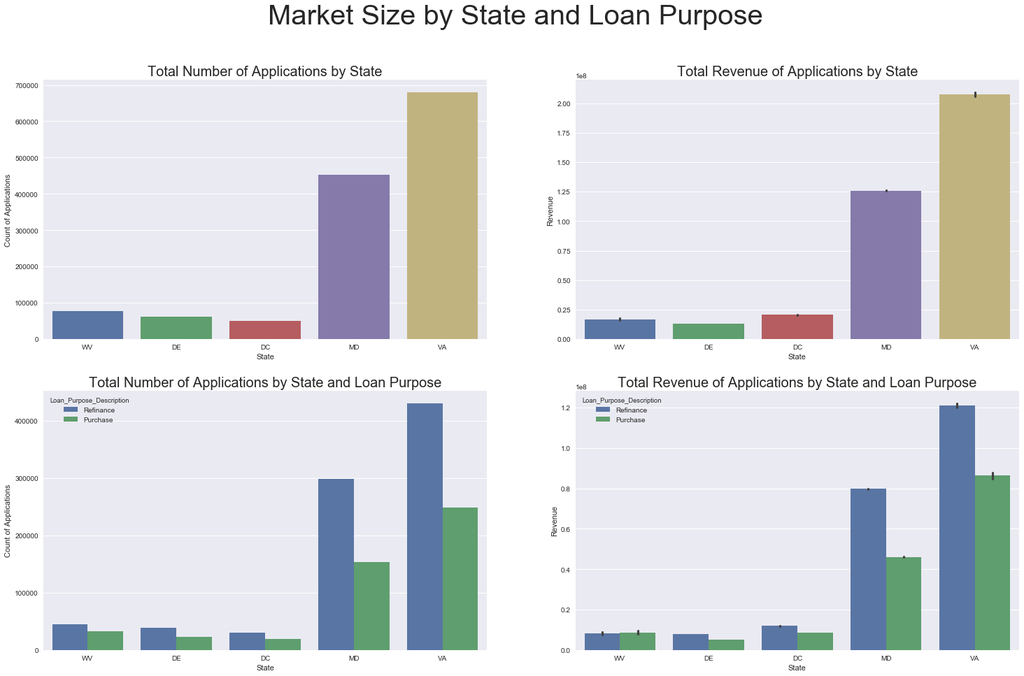

```python
createLoanAmountPlotByStateAndLoanPurpose(fd)
```

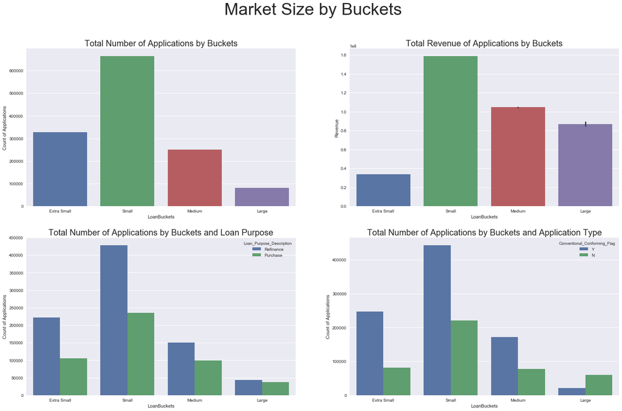

```python
createMarketShareByBuckets(fd)
```

**Loan Strategy**  
The Loan Baskets are defined based on the following strategy:

1. *Extra Small* : These are the loans which comes under the first quantile of the loan distribution. These are safe loans with a very low loan amount and thus, are less riskier. Range: (1 <= Loan_Amount_000 < 152)
2. *Small* : These are the loans which comes under the interquantile region of the loan distribution. These are safe loans with a very semi moderate loan amount have high popularity and exhibit high revenue generation. Range : (152 <= Loan_Amount_000 <= 347)
3. *Medium* : These are the loans which comes after the 3rd quantile region of the loan distribution. These have moderate loan amount and safe because majority of them come with the backing of being conventional and conforming. Range : (348 <= Loan_Amount_000 <= 550)
4. *Large* : These are the loans which comes after the 3rd quantile region of the loan distribution. These have high loan amount and are comparitively riskier because inconjuction of being high on loan amount very few of them are conventional and conforming. Range : (Loan_Amount_000 > 551)

**Analysis** Based on the aggregated data for the given years, it is clear that *Small* loans have been originated the most, followed by *Extra Small*, *Medium* and *Large*. *Small Loans* have also been the most revenue genearting bucket which signifies that *Small* bucket loans are more favourable because of the senergy between risk and revenue. On drilling the buckets down by Loan Purpose, it is significant that Refinance Loan mortgages has been originated the most in all the buckets which makes them more favorable for any lending organization. On drilling the buckets down by Conventional Conforming Flag, it is clear that loans which are both conventional and conforming are the most approving loans because of them being backed by Fannie Mae and Freddie Mac, as the lending institutions can sell their mortgages to Fannie Mae and Freddie Mac to reduce the risk.

**Conclusion**  
Based on the data provided, it is safe to say that Change Financial should enter the Lending Market and should follow in the footsteps of the existing lenders in the market by focussing on Conventional and Conforming Refinance loans. This move will be suitable for them as the they are trying to enter a new market and since there is no data about their financial and lending capability, they should start with a segment which has the senergy between risk and revenue. They should also take into consideration the Purchase Loans with certain guidlines which should be set based on their financial and lending capability.